# Figure 01

# 1) Setup

## - Defining work directory

In this section, we define the working directory for the R Markdown document.

```r
# Get the path of the current script
# Then get the parent directory of the parent directory of the parent directory
local_wd_folder <- dirname(dirname(dirname(rstudioapi::getSourceEditorContext()$path)))

# Set the root directory for knitr to the local working directory
knitr::opts_knit$set(root.dir = local_wd_folder)
```

## - Defining input data and output directories

Here, we define the directories for input data and output files.

```r
# Get the directory of the current script
script_folder <- dirname(rstudioapi::getSourceEditorContext()$path)

dir.create(paste(local_wd_folder, "/Data", sep = ''), showWarnings = F)

dir.create(paste(local_wd_folder, "/Figures", sep = ''), showWarnings = F)
dir.create(paste(local_wd_folder, "/Figures/Figure_01", sep = ''), showWarnings = F)
dir.create(paste(local_wd_folder, "/Figures/Figure_02", sep = ''), showWarnings = F)
dir.create(paste(local_wd_folder, "/Figures/Figure_03", sep = ''), showWarnings = F)
dir.create(paste(local_wd_folder, "/Figures/Figure_04", sep = ''), showWarnings = F)
dir.create(paste(local_wd_folder, "/Figures/Figure_05", sep = ''), showWarnings = F)
dir.create(paste(local_wd_folder, "/Figures/Figure_06", sep = ''), showWarnings = F)
dir.create(paste(local_wd_folder, "/Figures/Figure_07", sep = ''), showWarnings = F)
dir.create(paste(local_wd_folder, "/Figures/Supplemental", sep = ''), showWarnings = F)
dir.create(paste(local_wd_folder, "/Figures/Not_Included", sep = ''), showWarnings = F)

# Define the data folder and output folder
data_folder <- './Data'
output_folder <- './Figures/Figure_01'
```

## - Setting seed

Setting a seed ensures that any random processes are reproducible.

```r
# Set a seed for reproducibility
set.seed(123)
```

## - Packages installation (optional)

In this section, we ensure that all necessary packages are installed.

```r
# Ensure BiocManager is available for installation of Bioconductor packages
if (!requireNamespace("BiocManager", quietly = TRUE)) install.packages("BiocManager")

# Define a list of required packages used in this script
packages_required <- c("ComplexHeatmap", "stringr",
                        "unikn", "RColorBrewer", "yarrr",
                        "scales", "ggsci")

# Identify any required packages that are not installed
packages_uninstalled <- packages_required[!(packages_required %in% installed.packages()[,"Package"])]

# Install any uninstalled packages
if(length(packages_uninstalled)) BiocManager::install(packages_uninstalled)
```

## - Loading packages

Here, we load the necessary packages for our analysis.

```r
# Load stringr for string manipulation
library(stringr, quietly = TRUE)

# Load ComplexHeatmap for creating complex heatmaps
library(ComplexHeatmap, quietly = TRUE)
```

## - Loading palettes

In this section, we load additional color palettes and define some custom ones.

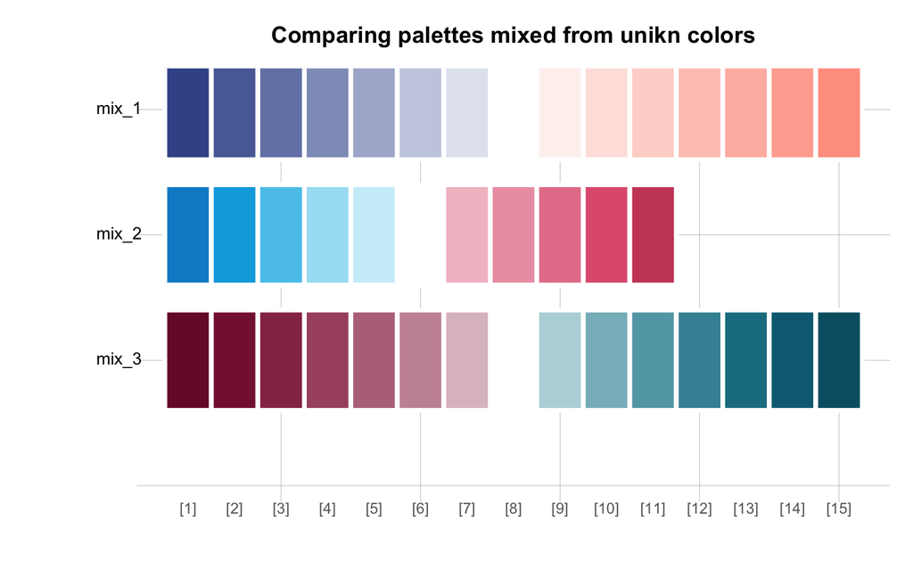

```r
# Load additional colour palette packages
library(unikn, quietly = TRUE)
library(RColorBrewer, quietly = TRUE)
library(yarrr, quietly = TRUE)
library(scales, quietly = TRUE)
library(ggsci, quietly = TRUE)

# Define a set of custom color palettes from the unikn package
mix_1 <- usecol(pal = c(Karpfenblau, "white", Peach), n = 15)
mix_2 <- usecol(pal = c(rev(pal_seeblau), "white", pal_pinky))
mix_3 <- usecol(pal = c(rev(pal_bordeaux), "white", pal_petrol), n = 15)

# Display the custom palettes
seecol(list(mix_1, mix_2, mix_3), col_brd = "white", lwd_brd = 4, title = "Comparing palettes mixed from unikn colors", pal_names = c("mix_1", "mix_2", "mix_3"))
```

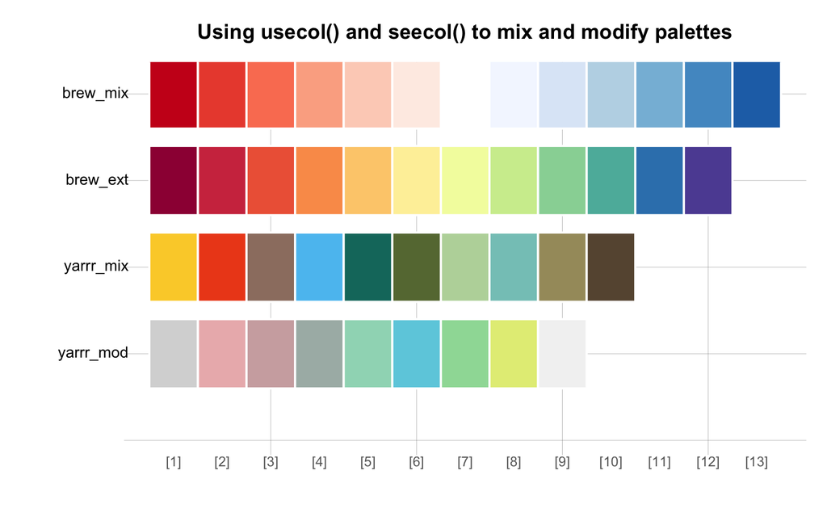

```r
# Define a second set of custom palettes from the RColorBrewer and yarrr packages
brew_mix <- usecol(c(rev(brewer.pal(n = 4, name = "Reds")), "white", brewer.pal(n = 4, name = "Blues")), n = 13)
brew_ext <- usecol(brewer.pal(n = 11, name = "Spectral"), n = 12)
yarrr_mix <- usecol(c(piratepal("nemo"), piratepal("bugs")))
yarrr_mod <- usecol(c(piratepal("ipod")), n = 9)

# Display the second set of custom palettes
seecol(pal = list(brew_mix, brew_ext, yarrr_mix, yarrr_mod), col_brd = "white", lwd_brd = 2, title = "Using usecol() and seecol() to mix and modify palettes", pal_names = c("brew_mix", "brew_ext", "yarrr_mix", "yarrr_mod"))
```

```r
# Define additional custom palettes from the scales package
natjournals_palette <- pal_npg("nrc")(10)
```

# 2) Panel A: Loading input files

Here we load two CSV files containing clinical and mutation metadata.

```r
Clinical_metadata <- read.csv(paste(data_folder, '/Oncoprint/Christie_BP-CMML_cohort_clinical_metadata.csv', sep = ''), row.names = 'Patient.ID')
Mutation_metadata <- read.csv(paste(data_folder, '/Oncoprint/Christie_BP-CMML_cohort_mutation_metadata.csv', sep = ''), row.names = 'Patient.ID')
```

# 3) Panel A: Heatmap

## - Mutation matrix colors

Here we transformsthe Mutation_metadata dataframe by converting numerical data into categorical data (‘MUT’ for ‘1’, and ’’ for ‘0’), then set up color mapping and rectangle drawing functions for heatmap visualization.

```r
# Loop over all columns in Mutation_metadata
for (colname in colnames(Mutation_metadata)) {
  # Convert the column to character
  Mutation_metadata[,colname] <- as.character(Mutation_metadata[,colname])
  # Replace '1' with 'MUT'
  Mutation_metadata[,colname] <- str_replace_all(Mutation_metadata[,colname], pattern = '1', replacement = 'MUT')
  # Replace '0' with ''
  Mutation_metadata[,colname] <- str_replace_all(Mutation_metadata[,colname], pattern = '0', replacement = '')
}

# Define a color mapping
col = c("MUT" = "grey25")

# Define a list of functions for drawing rectangles
alter_fun = list(
  # Function for drawing a light grey rectangle
  background = function(x, y, w, h) {
    grid.rect(x, y, w-unit(2, "pt"), h-unit(2, "pt"),
              gp = gpar(fill = "grey93", col = NA))
  },
  # Function for drawing a rectangle with the color defined for 'MUT'
  MUT = function(x, y, w, h) {
    grid.rect(x, y, w-unit(2, "pt"), h-unit(2, "pt"),
              gp = gpar(fill = col["MUT"], col = NA))
  }
)

# Define an empty column title
column_title = ""

# Define parameters for the heatmap legend
heatmap_legend_param = list(title = "Alternations", at = c("MUT"),
                            labels = c("Mutation"))
```

## - Selecting relevant clinical metadata for visualisation

Here we subsets ‘Clinical_metadata’ to keep relevant features.

```r
# Subset Clinical_metadata to keep only certain columns
Clinical_metadata_selected <- Clinical_metadata[,c('Cutaneous.BPDCN',
                                                   'ICC.classification',
                                                   'Cytogenetics.CPSS',
                                                   'Treatment.response',
                                                   'Upfront.HMA',
                                                   'Gender')]

# Subset Mutation_metadata to keep only the rows that have the same row names as Clinical_metadata_selected
Mutation_metadata <- Mutation_metadata[rownames(Clinical_metadata_selected),]
```

## - Defining categories and levels order

Here we convert several columns in Clinical_metadata_selected to factors with specific levels. We then rename the columns of ‘Clinical_metadata_selected’.

```r
# Convert 'Cutaneous.BPDCN' to a factor with levels 'No' and 'Yes'
Clinical_metadata_selected$Cutaneous.BPDCN <- factor(Clinical_metadata_selected$Cutaneous.BPDCN,
                                                     levels = c('No', 'Yes'))

# Convert 'ICC.classification' to a factor with specific levels
Clinical_metadata_selected$ICC.classification <- factor(Clinical_metadata_selected$ICC.classification,
                                                        levels = c('BPDCN',
                                                                   'AML not otherwise specified',
                                                                   'AML with CEBPA',
                                                                   'AML with NPM1',
                                                                   'AML with MDS-related gene mutations',
                                                                   'AML with MDS-related cytogenetic abnormalities'))

# Convert 'Cytogenetics.CPSS' to a factor with levels 'Low risk', 'Intermediate risk', and 'High risk'
Clinical_metadata_selected$Cytogenetics.CPSS <- factor(Clinical_metadata_selected$Cytogenetics.CPSS,
                                                       levels = c('Low risk',
                                                                  'Intermediate risk',
                                                                  'High risk'))

# Convert 'Treatment.response' to a factor with levels 'CR', 'Refractory', and 'Not evaluable'
Clinical_metadata_selected$Treatment.response <- factor(Clinical_metadata_selected$Treatment.response,
                                                        levels = c('CR',
                                                                   'Refractory',
                                                                   'Not evaluable'))

# Convert 'Upfront.HMA' to a factor with levels 'No' and 'Yes'
Clinical_metadata_selected$Upfront.HMA <- factor(Clinical_metadata_selected$Upfront.HMA,
                                                 levels = c('No',
                                                            'Yes'))

# Convert 'Gender' to a factor with levels 'Female' and 'Male'
Clinical_metadata_selected$Gender <- factor(Clinical_metadata_selected$Gender,
                                            levels = c('Female',
                                                       'Male'))

# Rename the columns of Clinical_metadata_selected
colnames(Clinical_metadata_selected) <- c('Cutaneous BPDCN',
                                          'ICC classification',
                                          'Cytogenetics (CPSS)',
                                          'Treatment response',
                                          'Upfront HMA',
                                          'Gender')
```

## - Heatmap columns metadata annotation colour

Here we define a list of color mappings for different categories in several variables.

```r
# Define a list of color mappings for different categories in several variables
colors_top_annotation <-  list(
  `Cutaneous BPDCN` = c('Yes' = '#b5179e',
                        'No' = '#ffd2fc'),
  `ICC classification` = c('BPDCN' = '#fff0f3',
                           'AML not otherwise specified' = '#ffccd5',
                           'AML with CEBPA' = '#ff8fa3',
                           'AML with NPM1' = '#ff4d6d',
                           'AML with MDS-related gene mutations' = '#c9184a',
                           'AML with MDS-related cytogenetic abnormalities' = '#800f2f'),
  `Cytogenetics (CPSS)` = c('Low risk' = '#ffdcc2',
                            'Intermediate risk' = '#eda268',
                            'High risk' = '#522500'),
  `Treatment response` = c('CR' = '#e9f5db',
                           'Refractory' = '#c2d5aa',
                           'Not evaluable' = '#606f49'),
  `Upfront HMA` = c('Yes' = '#72bbce',
                    'No' = '#dceef3'),
  Gender = c('Male' = '#e1e5f2',
             'Female' = '#bee3db')
)
```

## - Columns annotation

Here we create a heatmap annotation.

```r
# Create a heatmap annotation object
ha <- HeatmapAnnotation(
  df = Clinical_metadata_selected,
  gp = gpar(lwd = 2, col = 'white'),
  col = colors_top_annotation,
  show_annotation_name = TRUE,
  annotation_name_side = "left",
  show_legend = TRUE,
  annotation_name_gp = gpar(fontsize = 12, fontfamily = 'sans', fontface = 'bold'),
  annotation_legend_param = list(
    `Cutaneous BPDCN` = list(direction = "horizontal"),
    `ICC classification` = list(direction = "vertical"),
    `Cytogenetics (CPSS)` = list(direction = "vertical"),
    `Treatment response` = list(direction = "vertical"),
    `Upfront HMA` = list(direction = "horizontal"),
    `Gender` = list(direction = "horizontal")
  )
)
```

## - Heatmap styling

Here we set custom padding for the column and row annotations in a heatmap.

```r
# Set the padding for the column annotations to 0.4 cm
ht_opt$COLUMN_ANNO_PADDING = unit(0.4, "cm")

# Set the padding for the row annotations to 0.4 cm
ht_opt$ROW_ANNO_PADDING = unit(0.4, "cm")
```

## - Heatmap plotting

Here we create an oncoprint, which is a type of heatmap used in genomics to visualize gene mutations across multiple samples.

```r
# Create an oncoprint
oncoPrint_with_legend <- oncoPrint(t(Mutation_metadata),
                                   alter_fun = alter_fun,
                                   alter_fun_is_vectorized = FALSE,
                                   col = col,
                                   remove_empty_columns = TRUE,
                                   remove_empty_rows = TRUE,
                                   pct_side = "right", border = FALSE,
                                   row_names_side = "left",
                                   top_annotation = ha,
                                   pct_gp = gpar(fontsize = 12, fontfamily = 'sans'),
                                   row_names_gp = gpar(fontsize = 12, fontfamily = 'sans'),
                                   right_annotation =  rowAnnotation(rbar = anno_oncoprint_barplot()),
                                   left_annotation = NULL, show_heatmap_legend = TRUE,
                                   bottom_annotation =  columnAnnotation(botbar = anno_oncoprint_barplot(axis_param = list(direction = "reverse"))),
                                   column_title = column_title)
```

```
## All mutation types: MUT.
```

```r
# Now we save our plot:

# Open a new PNG device for plotting
png(filename = paste(output_folder, '/Panel_A.png', sep = ''), units = 'cm', width = 35, height = 22, res = 300)

# Draw the oncoprint on the current plotting device
draw(oncoPrint_with_legend, heatmap_legend_side = "right", annotation_legend_side = "right")

# Add text to the "rbar" annotation
decorate_annotation("rbar", {
  grid.text("Number of\nmutations\nin cohort", x = unit(10, "mm"), y = unit(165, "mm"), rot = 0, just = "bottom")
})

# Add text to the "botbar" annotation
decorate_annotation("botbar", {
  grid.text("Number of\nmutations\nin patient", x = unit(-9, "mm"), y = unit(10, "mm"), rot = 90, just = "bottom")
})

# Close the current plotting device
dev.off()
```

## - Plotting final result

Now that we saved our final oncoprint, let’s visualize it here.

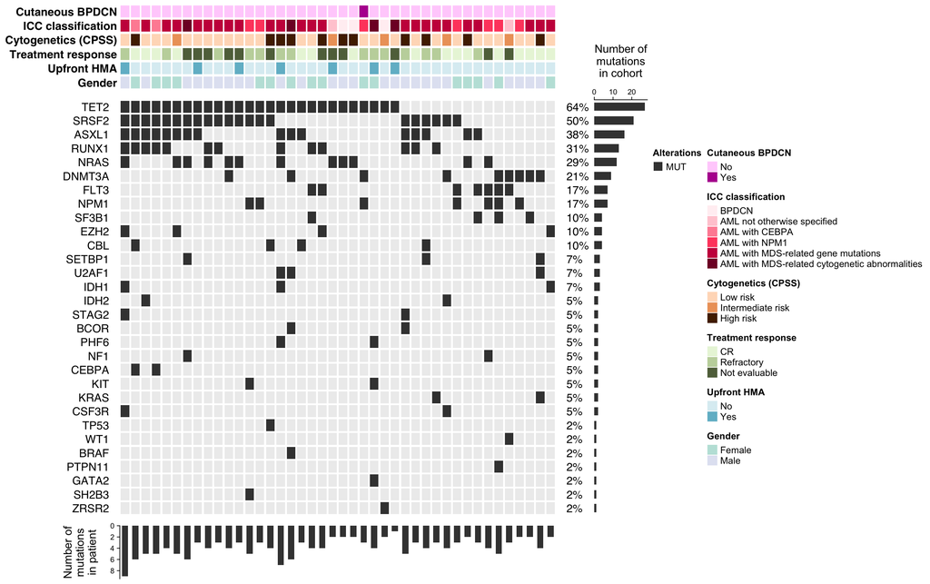

Figure 1A. Blast phase CMML displays distinctive clinical and molecular characteristics differentiating it from other forms of acute myeloid leukaemia